# 实验四 光谱定量分析工作流 近红外光谱预测玉米成分

2023HW4-郑元浩-22213014

数据集(mp5.csv)：包含 80 个玉米粉末样本，4 个成分指标，其中任意选择一个成分作为定量分析的目标。 要求：

1. 代码包含数据划分、交叉验证、数据预处理、构建定量模型、结果评估等主要流程；
2. 预处理过程包含 2 种以上方法及其组合；
3. 定量模型包含 2 种以上方法（如 PLSR 和 PCR），设定合理超参数搜索空间，使用网格搜索函数结合交叉验证实现超参数优化；
4. 使用均方根误差 RMSEP 和决定系数 R2评估结果。

问题：

1. 在你设计的工作流中，最优的模型组合是什么，预测集的精度多少； 最优的模型组合为：1diff+PLS，即一阶导数预处理+PLS建模，在此组合下预测集R2_test为0.911683
2. 预处理方法对模型的影响是积极的还是消极的，不同预处理方法之间是否存在相互作用； 以PLS建模方法为例，SG和MS预处理对模型几乎没有影响，一阶导数diff小幅提升了模型性能； 同样地，以SVM建模方法为例，SG和MS预处理对模型几乎没有影响，一阶导数diff小幅提升了模型性能； 不同预处理方法之间的组合（SG-MS）作用并不明显
3. 网格搜索的超参数空间是多少，交叉验证得到的最优超参数是多少；结合预处理方法后是否发生了变化。 PLS：11-11-10-7，结合预处理方法之后，发生了变化 SVM：100+poly,100+poly,100+linear,100+poly，也有发生变化的过程

# 导入模块

```python
import numpy as np
import pandas as pd
import random

from sklearn.model_selection import train_test_split
from sklearn.cross_decomposition import PLSRegression
from sklearn.discriminant_analysis import LinearDiscriminantAnalysis
from sklearn.svm import SVR
from sklearn.ensemble import RandomForestRegressor
from sklearn.tree import DecisionTreeRegressor
from sklearn.model_selection import KFold

from sklearn import preprocessing
from scipy.signal import savgol_filter
from sklearn.preprocessing import MinMaxScaler
from sklearn.model_selection import GridSearchCV
from sklearn.model_selection import RandomizedSearchCV
from sklearn.metrics import mean_squared_error
from sklearn.metrics import r2_score

import matplotlib.pyplot as plt
from IPython.core.pylabtools import figsize
```

## 一、原始数据

### 1.1 数据读取、查看与绘图

```python
df_raw = pd.read_csv('mp5.csv', header=0, index_col=0)
df_raw.head(5)
```

| 1100 | 1102 | 1104 | 1106 | 1108 | 1110 | 1112 | 1114 | 1116 | 1118 | 1120 | ... | 2488 | 2490 | 2492 | 2494 | 2496 | 2498 | moisture | oil | protein | starch |
| --- | --- | --- | --- | --- | --- | --- | --- | --- | --- | --- | --- | --- | --- | --- | --- | --- | --- | --- | --- | --- | --- |
| -0.012440 | -0.012514 | -0.012550 | -0.012519 | -0.012468 | -0.012356 | -0.012190 | -0.011983 | -0.011684 | -0.011296 | -0.010783 | ... | 0.684820 | 0.685216 | 0.685353 | 0.685223 | 0.684899 | 0.684377 | 10.448 | 3.687 | 8.746 | 64.838 |
| -0.014189 | -0.014251 | -0.014288 | -0.014264 | -0.014214 | -0.014106 | -0.013945 | -0.013756 | -0.013454 | -0.013078 | -0.012555 | ... | 0.692659 | 0.693017 | 0.693037 | 0.692842 | 0.692377 | 0.691869 | 10.409 | 3.720 | 8.658 | 64.851 |
| -0.013373 | -0.013439 | -0.013476 | -0.013456 | -0.013413 | -0.013314 | -0.013167 | -0.013003 | -0.012724 | -0.012368 | -0.011893 | ... | 0.663445 | 0.663723 | 0.663988 | 0.663755 | 0.663504 | 0.662983 | 10.313 | 3.496 | 9.125 | 63.567 |
| -0.016487 | -0.016543 | -0.016576 | -0.016573 | -0.016519 | -0.016414 | -0.016278 | -0.016096 | -0.015830 | -0.015473 | -0.014988 | ... | 0.659993 | 0.660412 | 0.660627 | 0.660580 | 0.660190 | 0.659695 | 10.260 | 3.504 | 9.389 | 63.263 |
| -0.008495 | -0.008567 | -0.008597 | -0.008566 | -0.008515 | -0.008388 | -0.008219 | -0.007997 | -0.007666 | -0.007237 | -0.006652 | ... | 0.728424 | 0.728744 | 0.728745 | 0.728585 | 0.728193 | 0.727811 | 10.292 | 3.661 | 8.952 | 64.148 |

5 rows × 703 columns

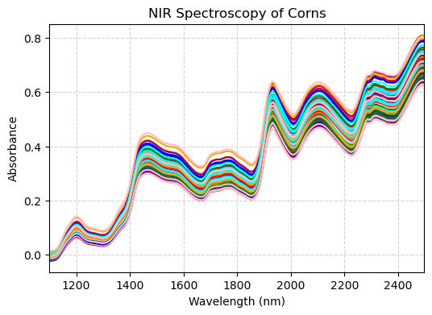

```python
# 绘制光谱数据
colors = ['red', 'blue', 'green','purple','orange','pink','cyan']
# 生成x轴数据
px = np.linspace(1100, 2498, num=699)
# 绘制光谱数据
fig, ax = plt.subplots(figsize=(6, 4))
for item in range(df_raw.shape[0]):
    py = df_raw.iloc[item, 0:df_raw.shape[1]-4]
    # 对每一条光谱产生随机的颜色
    plt.plot(px, py, color=random.choice(colors))
# 绘图细节
plt.xlim(1100, 2498)
plt.xlabel('Wavelength (nm)')
plt.ylabel('Absorbance')
plt.title('NIR Spectroscopy of Corns')
plt.grid(linestyle='--', which='major', color='lightgray')
plt.rcParams['figure.dpi'] = 200
```

### 1.2划分训练集与测试集

```python
df_train, df_test = train_test_split(df_raw, test_size=0.2, random_state=42)

print("训练集，测试集样本：")
( df_train.shape, df_test.shape )
```

```
训练集，测试集样本：
```

```
((64, 703), (16, 703))
```

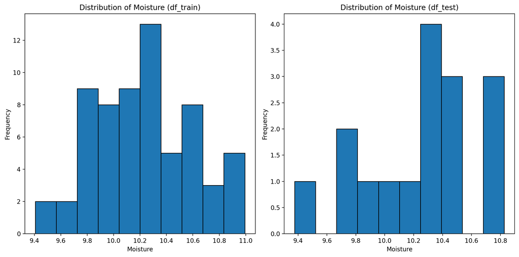

```python
# 查看训练集、测试集的moisture数据分布
# 创建一个包含两个子图的图形
fig, axes = plt.subplots(1, 2, figsize=(12, 6))
# 绘制df_train的直方图
axes[0].hist(df_train["moisture"], bins=10, edgecolor='black')
axes[0].set_title("Distribution of Moisture (df_train)")
axes[0].set_xlabel("Moisture")
axes[0].set_ylabel("Frequency")
# 绘制df_test的直方图
axes[1].hist(df_test["moisture"], bins=10, edgecolor='black')
axes[1].set_title("Distribution of Moisture (df_test)")
axes[1].set_xlabel("Moisture")
axes[1].set_ylabel("Frequency")
# 调整子图之间的间距
plt.tight_layout()
```

### 1.3 对训练集数据产生交叉验证的样本

```python
kf = KFold(n_splits=5, shuffle=False)

for train_index, valid_index in kf.split(df_train):
    print(train_index, valid_index)
```

```
[13 14 15 16 17 18 19 20 21 22 23 24 25 26 27 28 29 30 31 32 33 34 35 36
 37 38 39 40 41 42 43 44 45 46 47 48 49 50 51 52 53 54 55 56 57 58 59 60
 61 62 63] [ 0  1  2  3  4  5  6  7  8  9 10 11 12]
[ 0  1  2  3  4  5  6  7  8  9 10 11 12 26 27 28 29 30 31 32 33 34 35 36
 37 38 39 40 41 42 43 44 45 46 47 48 49 50 51 52 53 54 55 56 57 58 59 60
 61 62 63] [13 14 15 16 17 18 19 20 21 22 23 24 25]
[ 0  1  2  3  4  5  6  7  8  9 10 11 12 13 14 15 16 17 18 19 20 21 22 23
 24 25 39 40 41 42 43 44 45 46 47 48 49 50 51 52 53 54 55 56 57 58 59 60
 61 62 63] [26 27 28 29 30 31 32 33 34 35 36 37 38]
[ 0  1  2  3  4  5  6  7  8  9 10 11 12 13 14 15 16 17 18 19 20 21 22 23
 24 25 26 27 28 29 30 31 32 33 34 35 36 37 38 52 53 54 55 56 57 58 59 60
 61 62 63] [39 40 41 42 43 44 45 46 47 48 49 50 51]
[ 0  1  2  3  4  5  6  7  8  9 10 11 12 13 14 15 16 17 18 19 20 21 22 23
 24 25 26 27 28 29 30 31 32 33 34 35 36 37 38 39 40 41 42 43 44 45 46 47
 48 49 50 51] [52 53 54 55 56 57 58 59 60 61 62 63]
```

```python
# 生成交叉验证的子集index
kf = KFold(n_splits=5, shuffle=True, random_state=42)
lst_train_index = []
lst_valid_index = []
for train_index, valid_index in kf.split(df_train):
    lst_train_index.append(train_index)
    lst_valid_index.append(valid_index)
```

### 1.4 定义自变量X与因变量y的数据划分

```python
df_raw.shape
```

```
(80, 703)
```

```python
# 定义X,y划分函数
def X_y_split(df_raw):
    df_X = df_raw.iloc[:,0:df_raw.shape[1]-4]
    df_y = df_raw.iloc[:,df_raw.shape[1]-4]
    return df_X, df_y
```

```python
# 数据划分
X_train, y_train = X_y_split(df_train)
X_test, y_test = X_y_split(df_test)
print(train_index)
(X_train.shape , y_train.shape, X_test.shape , y_test.shape)
```

```
[ 0  1  2  3  4  5  6  8  9 11 12 13 15 16 17 19 21 23 24 25 26 27 29 30
 31 32 33 34 35 36 37 39 40 41 43 44 45 46 47 48 49 50 52 54 55 56 57 58
 59 60 61 62]
```

```
((64, 699), (64,), (16, 699), (16,))
```

### 1.5 PLS定量模型

```python
# 构建PLS模型,使用GridSearchCV函数实现交叉验证
pls = PLSRegression(scale=False)
param_dist = {'n_components':[k for k in range(1,50)]}
grid_search = GridSearchCV(estimator = pls, param_grid = param_dist, cv=5, scoring = 'neg_mean_squared_error')
grid_search.fit(X_train, y_train)
optim_estimator = grid_search.best_estimator_
y_train_pred = optim_estimator.predict(X_train)
y_test_pred = optim_estimator.predict(X_test)

# RMSE计算
rmse_train = np.sqrt(mean_squared_error(y_train, y_train_pred))
rmse_test = np.sqrt(mean_squared_error(y_test, y_test_pred))

# R2计算
r2_train = r2_score(y_train, y_train_pred)
r2_test = r2_score(y_test, y_test_pred)

print("Optimized hyperparamter:", grid_search.best_params_)

result_table = pd.DataFrame(columns=['Approaches','Training RMSE', 'Training R2','Test RMSE', 'Test R2'])
result = {'Approaches':'PLS','Training RMSE': rmse_train, 'Training R2': r2_train,'Test RMSE': rmse_test, 'Test R2': r2_test}
result_table = pd.concat([result_table, pd.DataFrame(result, index=[0])], ignore_index=True)
result_table
```

```
Optimized hyperparamter: {'n_components': 11}
```

|  | Approaches | Training RMSE | Training R2 | Test RMSE | Test R2 |
| --- | --- | --- | --- | --- | --- |
| 0 | PLS | 0.099386 | 0.929141 | 0.122198 | 0.904621 |

### 1.6 SVM定量模型

```python
# 构建SVM模型,使用GridSearchCV函数实现交叉验证
svm = SVR()
param_dist = {'C': [0.1, 1, 10, 20, 50, 100],
              'kernel': ['linear', 'rbf', 'poly']}
grid_search = GridSearchCV(estimator=svm, param_grid=param_dist, cv=5, scoring='neg_mean_squared_error')
grid_search.fit(X_train, y_train)
optim_estimator = grid_search.best_estimator_
y_train_pred = optim_estimator.predict(X_train)
y_test_pred = optim_estimator.predict(X_test)

# RMSE计算
rmse_train = np.sqrt(mean_squared_error(y_train, y_train_pred))
rmse_test = np.sqrt(mean_squared_error(y_test, y_test_pred))

# R2计算
r2_train = r2_score(y_train, y_train_pred)
r2_test = r2_score(y_test, y_test_pred)


print("Optimized hyperparamter:", grid_search.best_params_)

result = {'Approaches':'SVM','Training RMSE': rmse_train, 'Training R2': r2_train,'Test RMSE': rmse_test, 'Test R2': r2_test}
result_table = pd.concat([result_table, pd.DataFrame(result, index=[0])], ignore_index=True)
result_table
```

```
Optimized hyperparamter: {'C': 100, 'kernel': 'poly'}
```

|  | Approaches | Training RMSE | Training R2 | Test RMSE | Test R2 |
| --- | --- | --- | --- | --- | --- |
| 0 | PLS | 0.099386 | 0.929141 | 0.122198 | 0.904621 |
| 1 | SVM | 0.157469 | 0.822116 | 0.151156 | 0.854058 |

## 二、SG平滑数据

### 2.1 SG平滑处理

```python
# SG平滑处理
X_train_SG = savgol_filter(X_train, window_length=13, polyorder=2) # 人为设定用于平滑的多项式窗口大小和次数
X_test_SG = savgol_filter(X_test, window_length=13, polyorder=2)
X_train_SG = pd.DataFrame(X_train_SG, index=X_train.index, columns=X_train.columns)
X_test_SG = pd.DataFrame(X_test_SG, index=X_test.index, columns=X_test.columns)
df_train_SG = pd.concat([X_train_SG ,y_train], axis=1)
```

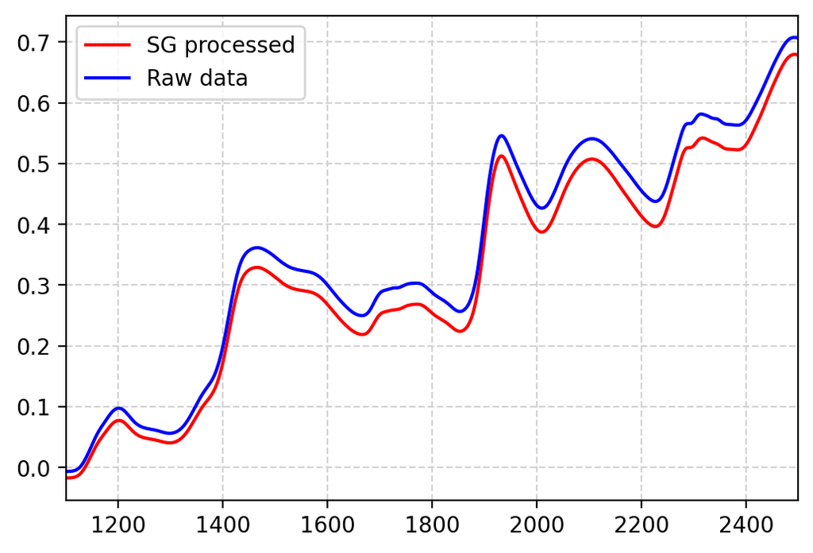

```python
# 查看SG平滑结果
figsize(6, 4)
px = np.linspace(1100, 2498, num=699)
py = X_train_SG.iloc[2,:]
plt.plot(px, py, color='red', label='SG processed')
plt.plot(px, X_train.iloc[1,:], color='blue', label='Raw data')
plt.grid(linestyle='--', which='major', color = 'lightgray')
plt.rcParams['figure.dpi'] = 300
plt.xlim(1100, 2498)
plt.legend()
```

### 2.2 SG平滑处理 建模结果

```python
# 构建PLS模型,使用GridSearchCV函数实现交叉验证
pls = PLSRegression(scale=False)
param_dist = {'n_components':[k for k in range(1,50)]}
grid_search = GridSearchCV(estimator = pls, param_grid = param_dist,
                           cv=5, scoring = 'neg_mean_squared_error')
grid_search.fit(X_train_SG, y_train)
optim_estimator = grid_search.best_estimator_
y_train_SG_pred = optim_estimator.predict(X_train_SG)
y_test_SG_pred = optim_estimator.predict(X_test_SG)

# RMSE计算
rmse_train = np.sqrt(mean_squared_error(y_train, y_train_SG_pred))
rmse_test = np.sqrt(mean_squared_error(y_test, y_test_SG_pred))

# R2计算
r2_train = r2_score(y_train, y_train_SG_pred)
r2_test = r2_score(y_test, y_test_SG_pred)


print("Optimized hyperparamter:", grid_search.best_params_)

result = {'Approaches':'SG-PLS','Training RMSE': rmse_train, 'Training R2': r2_train,'Test RMSE': rmse_test, 'Test R2': r2_test}
result_table = pd.concat([result_table, pd.DataFrame(result, index=[0])], ignore_index=True)
result_table
```

```
Optimized hyperparamter: {'n_components': 11}
```

|  | Approaches | Training RMSE | Training R2 | Test RMSE | Test R2 |
| --- | --- | --- | --- | --- | --- |
| 0 | PLS | 0.099386 | 0.929141 | 0.122198 | 0.904621 |
| 1 | SVM | 0.157469 | 0.822116 | 0.151156 | 0.854058 |
| 2 | SG-PLS | 0.100169 | 0.928019 | 0.121798 | 0.905244 |

```python
# 构建SVM模型,使用GridSearchCV函数实现交叉验证
svm = SVR()
param_dist = {'C': [0.1, 1, 10, 20, 50, 100],
              'kernel': ['linear', 'rbf', 'poly']}
grid_search = GridSearchCV(estimator=svm, param_grid=param_dist, cv=5, scoring='neg_mean_squared_error')
grid_search.fit(X_train_SG, y_train)
optim_estimator = grid_search.best_estimator_
y_train_SG_pred = optim_estimator.predict(X_train_SG)
y_test_SG_pred = optim_estimator.predict(X_test_SG)

# RMSE计算
rmse_train = np.sqrt(mean_squared_error(y_train, y_train_SG_pred))
rmse_test = np.sqrt(mean_squared_error(y_test, y_test_SG_pred))

# R2计算
r2_train = r2_score(y_train, y_train_SG_pred)
r2_test = r2_score(y_test, y_test_SG_pred)


print("Optimized hyperparamter:", grid_search.best_params_)

result = {'Approaches':'SG-SVM','Training RMSE': rmse_train, 'Training R2': r2_train,'Test RMSE': rmse_test, 'Test R2': r2_test}
result_table = pd.concat([result_table, pd.DataFrame(result, index=[0])], ignore_index=True)
result_table
```

```
Optimized hyperparamter: {'C': 100, 'kernel': 'poly'}
```

|  | Approaches | Training RMSE | Training R2 | Test RMSE | Test R2 |
| --- | --- | --- | --- | --- | --- |
| 0 | PLS | 0.099386 | 0.929141 | 0.122198 | 0.904621 |
| 1 | SVM | 0.157469 | 0.822116 | 0.151156 | 0.854058 |
| 2 | SG-PLS | 0.100169 | 0.928019 | 0.121798 | 0.905244 |
| 3 | SG-SVM | 0.157474 | 0.822104 | 0.150866 | 0.854618 |

## 三、Min-max归一化数据

### 3.1 Min-max归一化处理

```python
# 定义Min-max归一化方法
def scale_column(X_train, X_test):
    scaler = preprocessing.MinMaxScaler().fit(X_train)
    X_train_scaled = scaler.transform(X_train)
    X_test_scaled = scaler.transform(X_test)
    return X_train_scaled, X_test_scaled
```

```python
# Min-max归一化原始数据
X_train_MS, X_test_MS = scale_column(X_train, X_test)
X_train_MS = pd.DataFrame(X_train_MS, index=X_train.index, columns=X_train.columns)
X_test_MS = pd.DataFrame(X_test_MS, index=X_test.index, columns=X_test.columns)
df_train_MS = pd.concat([X_train_MS, y_train], axis=1)
```

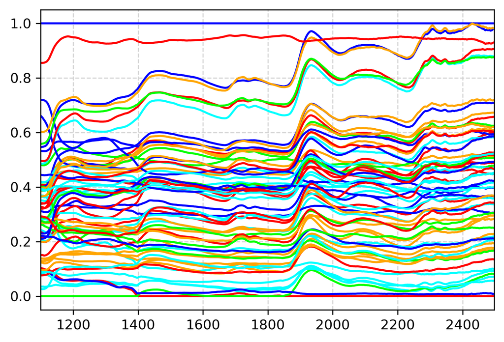

```python
# 查看Min-max归一化结果
figsize(6, 4)
px = np.linspace(1100, 2498, num=699)
colors = ['blue', 'lime', 'red', 'cyan', 'orange']
for item in range(X_train.shape[0]):
    py = X_train_MS.iloc[item,:]
    plt.plot(px, py, color=random.choice(colors))

plt.xlim(1100, 2498)
plt.grid(linestyle='--', which='major', color='lightgray')
plt.rcParams['figure.dpi'] = 300
```

### 3.2 Min-max归一化 建模结果

```python
# 构建PLS模型,使用GridSearchCV函数实现交叉验证
pls = PLSRegression(scale=False)
param_dist = {'n_components':[k for k in range(1,50)]}
grid_search = GridSearchCV(estimator = pls, param_grid = param_dist,
                           cv=5, scoring = 'neg_mean_squared_error')
grid_search.fit(X_train_MS, y_train)
optim_estimator = grid_search.best_estimator_
y_train_MS_pred = optim_estimator.predict(X_train_MS)
y_test_MS_pred = optim_estimator.predict(X_test_MS)

# RMSE计算
rmse_train = np.sqrt(mean_squared_error(y_train, y_train_MS_pred))
rmse_test = np.sqrt(mean_squared_error(y_test, y_test_MS_pred))

# R2计算
r2_train = r2_score(y_train, y_train_MS_pred)
r2_test = r2_score(y_test, y_test_MS_pred)


print("Optimized hyperparamter:", grid_search.best_params_)

result = {'Approaches':'MS-PLS','Training RMSE': rmse_train, 'Training R2': r2_train,'Test RMSE': rmse_test, 'Test R2': r2_test}
result_table = pd.concat([result_table, pd.DataFrame(result, index=[0])], ignore_index=True)
result_table
```

```
Optimized hyperparamter: {'n_components': 10}
```

|  | Approaches | Training RMSE | Training R2 | Test RMSE | Test R2 |
| --- | --- | --- | --- | --- | --- |
| 0 | PLS | 0.099386 | 0.929141 | 0.122198 | 0.904621 |
| 1 | SVM | 0.157469 | 0.822116 | 0.151156 | 0.854058 |
| 2 | SG-PLS | 0.100169 | 0.928019 | 0.121798 | 0.905244 |
| 3 | SG-SVM | 0.157474 | 0.822104 | 0.150866 | 0.854618 |
| 4 | MS-PLS | 0.103018 | 0.923867 | 0.127093 | 0.896825 |

```python
# 构建SVM模型,使用GridSearchCV函数实现交叉验证
svm = SVR()
param_dist = {'C': [0.1, 1, 10, 20, 50, 100],
              'kernel': ['linear', 'rbf', 'poly']}
grid_search = GridSearchCV(estimator=svm, param_grid=param_dist, cv=5, scoring='neg_mean_squared_error')
grid_search.fit(X_train_MS, y_train)
optim_estimator = grid_search.best_estimator_
y_train_MS_pred = optim_estimator.predict(X_train_MS)
y_test_MS_pred = optim_estimator.predict(X_test_MS)

# RMSE计算
rmse_train = np.sqrt(mean_squared_error(y_train, y_train_MS_pred))
rmse_test = np.sqrt(mean_squared_error(y_test, y_test_MS_pred))

# R2计算
r2_train = r2_score(y_train, y_train_MS_pred)
r2_test = r2_score(y_test, y_test_MS_pred)


print("Optimized hyperparamter:", grid_search.best_params_)

result = {'Approaches':'MS-SVM','Training RMSE': rmse_train, 'Training R2': r2_train,'Test RMSE': rmse_test, 'Test R2': r2_test}
result_table = pd.concat([result_table, pd.DataFrame(result, index=[0])], ignore_index=True)
result_table
```

```
Optimized hyperparamter: {'C': 100, 'kernel': 'linear'}
```

|  | Approaches | Training RMSE | Training R2 | Test RMSE | Test R2 |
| --- | --- | --- | --- | --- | --- |
| 0 | PLS | 0.099386 | 0.929141 | 0.122198 | 0.904621 |
| 1 | SVM | 0.157469 | 0.822116 | 0.151156 | 0.854058 |
| 2 | SG-PLS | 0.100169 | 0.928019 | 0.121798 | 0.905244 |
| 3 | SG-SVM | 0.157474 | 0.822104 | 0.150866 | 0.854618 |
| 4 | MS-PLS | 0.103018 | 0.923867 | 0.127093 | 0.896825 |
| 5 | MS-SVM | 0.103799 | 0.922708 | 0.157481 | 0.841589 |

## 四、SG平滑 + Min-max归一化数据

### 4.1 SG平滑 + Min-max归一化处理

```python
# SG平滑 + Min-max归一化
X_train_SG_MS, X_test_SG_MS= scale_column(X_train_SG, X_test_SG)
X_train_SG_MS = pd.DataFrame(X_train_SG_MS, index=X_train.index, columns=X_train.columns)
X_test_SG_MS = pd.DataFrame(X_test_SG_MS, index=X_test.index, columns=X_test.columns)
df_train_SG_MS = pd.concat([X_train_SG_MS,y_train], axis=1)
```

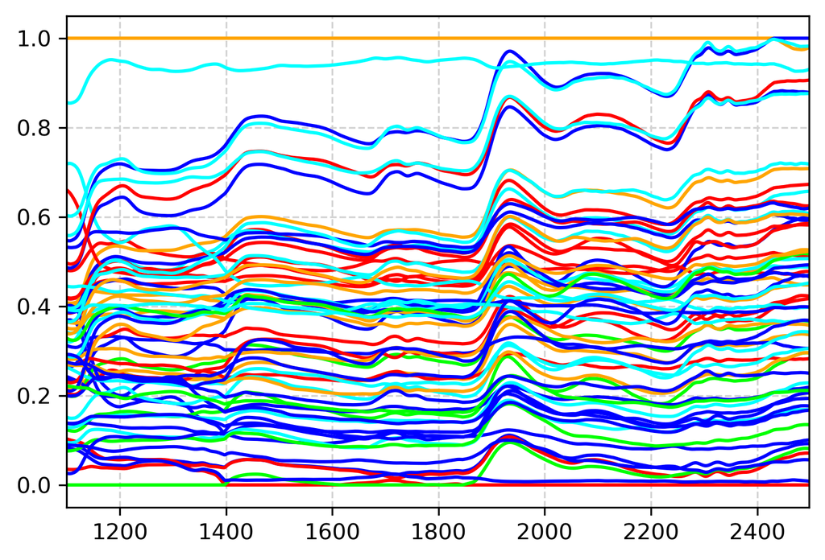

```python
# 查看SG平滑+Min-max归一化结果
figsize(6, 4)
px = np.linspace(1100, 2498, num=699)
colors = ['blue', 'lime', 'red', 'cyan', 'orange']
for item in range(X_train.shape[0]):
    py = X_train_SG_MS.iloc[item,:]
    plt.plot(px, py, color=random.choice(colors))
plt.grid(linestyle='--',which='major',color = 'lightgray')
plt.xlim(1100, 2498)
plt.rcParams['figure.dpi'] = 300
```

### 4.2 SG平滑 + Min-max归一化 建模结果

```python
# 构建PLS模型,使用GridSearchCV函数实现交叉验证
pls = PLSRegression(scale=False)
param_dist = {'n_components':[k for k in range(1,50)]}
grid_search = GridSearchCV(estimator = pls, param_grid = param_dist,
                           cv=5, scoring = 'neg_mean_squared_error')
grid_search.fit(X_train_SG_MS, y_train)
optim_estimator = grid_search.best_estimator_
y_train_SG_MS_pred = optim_estimator.predict(X_train_SG_MS)
y_test_SG_MS_pred = optim_estimator.predict(X_test_SG_MS)

# RMSE计算
rmse_train = np.sqrt(mean_squared_error(y_train, y_train_SG_MS_pred))
rmse_test = np.sqrt(mean_squared_error(y_test, y_test_SG_MS_pred))

# R2计算
r2_train = r2_score(y_train, y_train_SG_MS_pred)
r2_test = r2_score(y_test, y_test_SG_MS_pred)


print("Optimized hyperparamter:", grid_search.best_params_)

result = {'Approaches':'SG-MS-PLS','Training RMSE': rmse_train, 'Training R2': r2_train,'Test RMSE': rmse_test, 'Test R2': r2_test}
result_table = pd.concat([result_table, pd.DataFrame(result, index=[0])], ignore_index=True)
result_table
```

```
Optimized hyperparamter: {'n_components': 10}
```

|  | Approaches | Training RMSE | Training R2 | Test RMSE | Test R2 |
| --- | --- | --- | --- | --- | --- |
| 0 | PLS | 0.099386 | 0.929141 | 0.122198 | 0.904621 |
| 1 | SVM | 0.157469 | 0.822116 | 0.151156 | 0.854058 |
| 2 | SG-PLS | 0.100169 | 0.928019 | 0.121798 | 0.905244 |
| 3 | SG-SVM | 0.157474 | 0.822104 | 0.150866 | 0.854618 |
| 4 | MS-PLS | 0.103018 | 0.923867 | 0.127093 | 0.896825 |
| 5 | MS-SVM | 0.103799 | 0.922708 | 0.157481 | 0.841589 |
| 6 | SG-MS-PLS | 0.103294 | 0.923459 | 0.127159 | 0.896719 |

```python
# 构建SVM模型,使用GridSearchCV函数实现交叉验证
svm = SVR()
param_dist = {'C': [0.1, 1, 10, 20, 50, 100],
              'kernel': ['linear', 'rbf', 'poly']}
grid_search = GridSearchCV(estimator=svm, param_grid=param_dist, cv=5, scoring='neg_mean_squared_error')
grid_search.fit(X_train_SG_MS, y_train)
optim_estimator = grid_search.best_estimator_
y_train_SG_MS_pred = optim_estimator.predict(X_train_SG_MS)
y_test_SG_MS_pred = optim_estimator.predict(X_test_SG_MS)

# RMSE计算
rmse_train = np.sqrt(mean_squared_error(y_train, y_train_SG_MS_pred))
rmse_test = np.sqrt(mean_squared_error(y_test, y_test_SG_MS_pred))

# R2计算
r2_train = r2_score(y_train, y_train_SG_MS_pred)
r2_test = r2_score(y_test, y_test_SG_MS_pred)


print("Optimized hyperparamter:", grid_search.best_params_)

result = {'Approaches':'SG-MS-SVM','Training RMSE': rmse_train, 'Training R2': r2_train,'Test RMSE': rmse_test, 'Test R2': r2_test}
result_table = pd.concat([result_table, pd.DataFrame(result, index=[0])], ignore_index=True)
result_table
```

```
Optimized hyperparamter: {'C': 100, 'kernel': 'linear'}
```

|  | Approaches | Training RMSE | Training R2 | Test RMSE | Test R2 |
| --- | --- | --- | --- | --- | --- |
| 0 | PLS | 0.099386 | 0.929141 | 0.122198 | 0.904621 |
| 1 | SVM | 0.157469 | 0.822116 | 0.151156 | 0.854058 |
| 2 | SG-PLS | 0.100169 | 0.928019 | 0.121798 | 0.905244 |
| 3 | SG-SVM | 0.157474 | 0.822104 | 0.150866 | 0.854618 |
| 4 | MS-PLS | 0.103018 | 0.923867 | 0.127093 | 0.896825 |
| 5 | MS-SVM | 0.103799 | 0.922708 | 0.157481 | 0.841589 |
| 6 | SG-MS-PLS | 0.103294 | 0.923459 | 0.127159 | 0.896719 |
| 7 | SG-MS-SVM | 0.104448 | 0.921738 | 0.157738 | 0.841073 |

## 五、一阶导数预处理

### 5.1 一阶导数 光谱预处理

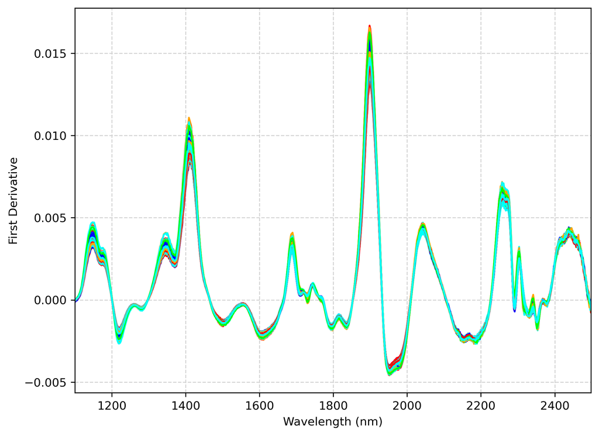

```python
#一阶导数
X_train_diff = np.diff(X_train, axis=1)
X_test_diff = np.diff(X_test, axis=1)
X_train_diff = pd.DataFrame(X_train_diff, index=X_train.index, columns=X_train.columns[1:])
X_test_diff = pd.DataFrame(X_test_diff, index=X_test.index, columns=X_test.columns[1:])
df_train_diff = pd.concat([X_train_diff, y_train], axis=1)

fig, ax = plt.subplots(figsize=(8, 6))
px = np.linspace(1100, 2498, num=698)
colors = ['blue', 'lime', 'red', 'cyan', 'orange']
for item in range(X_train_diff.shape[0]):
    py = X_train_diff.iloc[item, :]
    plt.plot(px, py, color=random.choice(colors))

plt.xlim(1100, 2498)
plt.grid(linestyle='--', which='major', color='lightgray')
plt.xlabel('Wavelength (nm)')
plt.ylabel('First Derivative')
plt.rcParams['figure.dpi'] = 200
```

### 5.2 一阶导数预处理 建模结果

```python
# 构建PLS模型,使用GridSearchCV函数实现交叉验证
pls = PLSRegression(scale=False)
param_dist = {'n_components':[k for k in range(1,10)]}
grid_search = GridSearchCV(estimator = pls, param_grid = param_dist, cv=5, scoring = 'neg_mean_squared_error')
grid_search.fit(X_train_diff, y_train)
optim_estimator = grid_search.best_estimator_
y_train_diff_pred = optim_estimator.predict(X_train_diff)
y_test_diff_pred = optim_estimator.predict(X_test_diff)

# RMSE计算
rmse_train = np.sqrt(mean_squared_error(y_train, y_train_diff_pred))
rmse_test = np.sqrt(mean_squared_error(y_test, y_test_diff_pred))

# R2计算
r2_train = r2_score(y_train, y_train_diff_pred)
r2_test = r2_score(y_test, y_test_diff_pred)

print("Optimized hyperparamter:", grid_search.best_params_)

result = {'Approaches':'1diff-PLS','Training RMSE': rmse_train, 'Training R2': r2_train,'Test RMSE': rmse_test, 'Test R2': r2_test}
result_table = pd.concat([result_table, pd.DataFrame(result, index=[0])], ignore_index=True)
result_table
```

```
Optimized hyperparamter: {'n_components': 7}
```

|  | Approaches | Training RMSE | Training R2 | Test RMSE | Test R2 |
| --- | --- | --- | --- | --- | --- |
| 0 | PLS | 0.099386 | 0.929141 | 0.122198 | 0.904621 |
| 1 | SVM | 0.157469 | 0.822116 | 0.151156 | 0.854058 |
| 2 | SG-PLS | 0.100169 | 0.928019 | 0.121798 | 0.905244 |
| 3 | SG-SVM | 0.157474 | 0.822104 | 0.150866 | 0.854618 |
| 4 | MS-PLS | 0.103018 | 0.923867 | 0.127093 | 0.896825 |
| 5 | MS-SVM | 0.103799 | 0.922708 | 0.157481 | 0.841589 |
| 6 | SG-MS-PLS | 0.103294 | 0.923459 | 0.127159 | 0.896719 |
| 7 | SG-MS-SVM | 0.104448 | 0.921738 | 0.157738 | 0.841073 |
| 8 | 1diff-PLS | 0.073574 | 0.961168 | 0.117586 | 0.911683 |

```python
# 构建SVM模型,使用GridSearchCV函数实现交叉验证
svm = SVR()
param_dist = {'C': [0.1, 1, 10, 20, 50, 100],
              'kernel': ['linear', 'rbf', 'poly']}
grid_search = GridSearchCV(estimator=svm, param_grid=param_dist, cv=5, scoring='neg_mean_squared_error')
grid_search.fit(X_train_diff, y_train)
optim_estimator = grid_search.best_estimator_
y_train_diff_pred = optim_estimator.predict(X_train_diff)
y_test_diff_pred = optim_estimator.predict(X_test_diff)

# RMSE计算
rmse_train = np.sqrt(mean_squared_error(y_train, y_train_diff_pred))
rmse_test = np.sqrt(mean_squared_error(y_test, y_test_diff_pred))

# R2计算
r2_train = r2_score(y_train, y_train_diff_pred)
r2_test = r2_score(y_test, y_test_diff_pred)


print("Optimized hyperparamter:", grid_search.best_params_)

result = {'Approaches':'1diff-SVM','Training RMSE': rmse_train, 'Training R2': r2_train,'Test RMSE': rmse_test, 'Test R2': r2_test}
result_table = pd.concat([result_table, pd.DataFrame(result, index=[0])], ignore_index=True)
result_table
```

```
Optimized hyperparamter: {'C': 100, 'kernel': 'poly'}
```

|  | Approaches | Training RMSE | Training R2 | Test RMSE | Test R2 |
| --- | --- | --- | --- | --- | --- |
| 0 | PLS | 0.099386 | 0.929141 | 0.122198 | 0.904621 |
| 1 | SVM | 0.157469 | 0.822116 | 0.151156 | 0.854058 |
| 2 | SG-PLS | 0.100169 | 0.928019 | 0.121798 | 0.905244 |
| 3 | SG-SVM | 0.157474 | 0.822104 | 0.150866 | 0.854618 |
| 4 | MS-PLS | 0.103018 | 0.923867 | 0.127093 | 0.896825 |
| 5 | MS-SVM | 0.103799 | 0.922708 | 0.157481 | 0.841589 |
| 6 | SG-MS-PLS | 0.103294 | 0.923459 | 0.127159 | 0.896719 |
| 7 | SG-MS-SVM | 0.104448 | 0.921738 | 0.157738 | 0.841073 |
| 8 | 1diff-PLS | 0.073574 | 0.961168 | 0.117586 | 0.911683 |
| 9 | 1diff-SVM | 0.150450 | 0.837619 | 0.128775 | 0.894077 |

1. 在你设计的工作流中，最优的模型组合是什么，预测集的精度多少； 最优的模型组合为：1diff+PLS，即一阶导数预处理+PLS建模，在此组合下预测集R2_test为0.911683
2. 预处理方法对模型的影响是积极的还是消极的，不同预处理方法之间是否存在相互作用； 以PLS建模方法为例，SG和MS预处理对模型几乎没有影响，一阶导数diff小幅提升了模型性能； 同样地，以SVM建模方法为例，SG和MS预处理对模型几乎没有影响，一阶导数diff小幅提升了模型性能； 不同预处理方法之间的组合（SG-MS）作用并不明显
3. 网格搜索的超参数空间是多少，交叉验证得到的最优超参数是多少；结合预处理方法后是否发生了变化。 PLS：11-11-10-7，结合预处理方法之后，发生了变化 SVM：100+poly,100+poly,100+linear,100+poly，也有发生变化的过程